# 1.1: Introduction

October 21, 2019

## Contents

### **Day 1**

- statistical models & the likelihood
- Bayesian principles
- Stan: a probabilistic programming language
- my first Stan model

### **Day 2**

- priors
- interpreting results & working with the posterior distribution
- more classical models

### **Day 3**

- hierarchical models
- resources
- summary

## Goals

- think in terms of: model, data, parameters
- building blocks of statistics
- not be intimidated by Bayesian stats
- understand basic examples
- write code in Stan
- interpret model output
- **build your own models**

## Survey

Which statistical methods / models have you used before?

## Terminology

- \(p(y)\) probability density function
- \(P(A)=P(y\in A)=\int_A p(y)dy\) probability of the event \(A\):  
  e.g. \(P(y>0)=P(y\in[0,\infty])=\int_0^\infty p(y)dy\)
- \(P(A|B)\) conditional probability:  
  probability of \(A\), given \(B\) already occured
- \(y\sim\text{normal}(\mu,\sigma)\):  
  \(y\) is a normally distributed random variable  
  with mean \(\mu\) and standard deviation \(\sigma\)
- know your distribution! https://ben18785.shinyapps.io/distribution-zoo/

## Statistical modeling

- data are described by underlying statistical model
- model: deterministic and stochastic part
- **deterministic part**: mechanistic, phenomenological
- **stochastic part**: connects mechanistic part to the data
- inference: what can the data tell me about my model?

## A basic example: linear regression

\(y_i \sim \text{normal}(\mu_i,\sigma)\quad i=1,...,n\)

\(\mu_i = a+b\cdot x_i\)

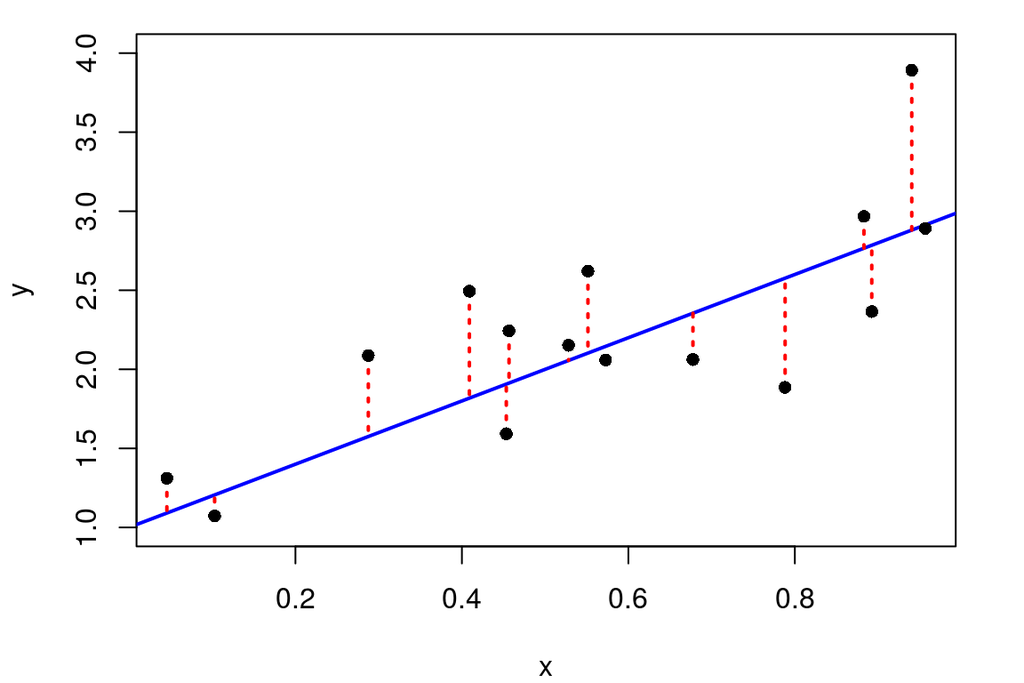

## A basic example: linear regression

\(y_i \sim \text{normal}(\mu_i,\sigma)\quad i=1,...,n\)

\(\mu_i = a+b\cdot x_i\)

- data: \(x_i, y_i,\quad i=1,...,n\)
- parameters: \(a,b,\sigma\)
- deterministic part: \(\mu_i = a+b\cdot x_i\)
- stochastic part: \(y_i \sim \text{normal}(\mu_i,\sigma)\)  
  or written as residuals: \(\epsilon_i = y_i -\mu_i \sim \text{normal}(0,\sigma)\)

## A basic example: linear regression

\(y_i \sim \text{normal}(\mu_i,\sigma)\quad i=1,...,n\)

\(\mu_i = a+b\cdot x_i\)

### do the data have to be normally distributed?

- common misconception, even in some textbooks!
- each datapoint \(y_i\) is normally distributed with a "shifting" mean \(\mu_i\) (\(y_i\) are **not** iid)
- so the data \(y_1,\dots,y_n\) are **not** normally distributed with a joint mean \(\mu\)
- but the residuals \(\epsilon_i = y_i-\mu_i\sim \text{normal}(0,\sigma)\) are iid with zero mean!
- generally, there are no assumptions on the raw data, but on the residuals!

## Even simpler: estimating the mean

Yes, this is already a statistical model!

\(y_i \sim \text{normal}(\mu,\sigma)\quad i=1,...,n\)

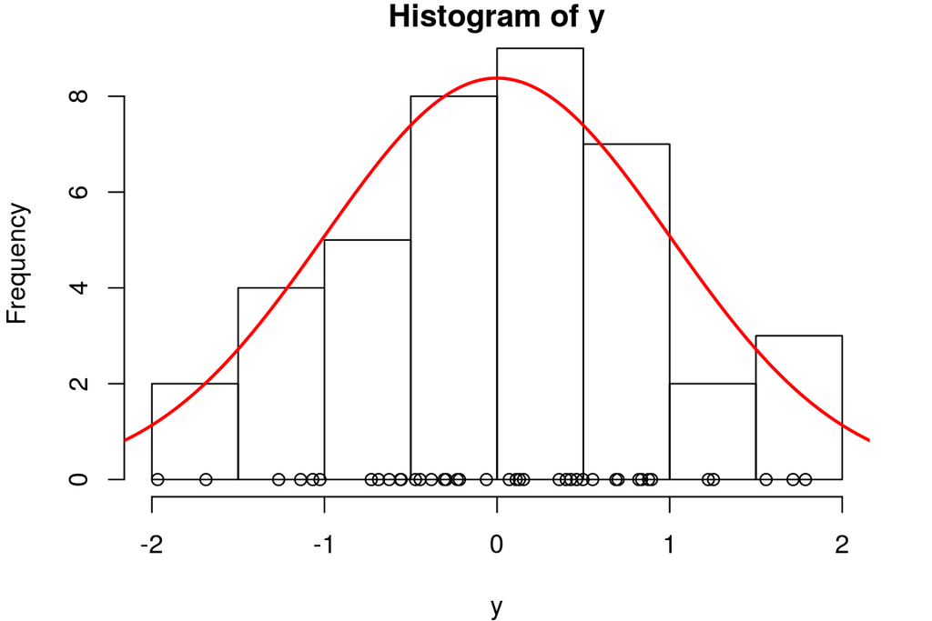

## The likelihood function

- a single datapoint \(y_i\)
- probability density function \(p()\)
- here: normal distribution \(y_i\sim \text{normal}(\mu,\sigma)\)
- \(p(y_i | \mu,\sigma) = \frac{1}{\sqrt{2\pi\sigma}}e^{-\frac{(y_i-\mu)^2}{2\sigma^2} }\)

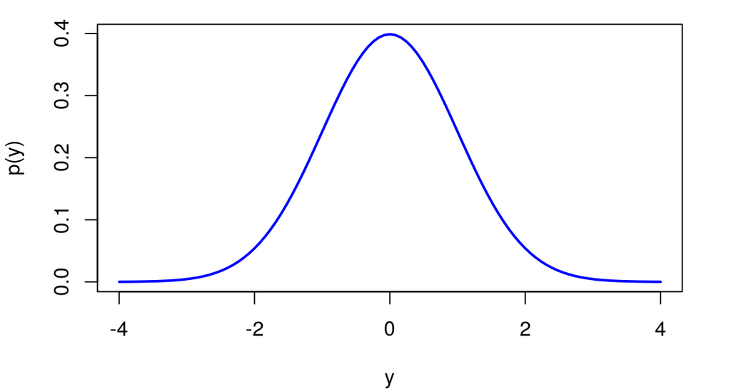

## Maximum likelihood principle

Find parameters \(\theta=(\mu,\sigma)\) that maximize likelihood of all datapoints \(y_1,...,y_n\) simultaneously!

Or: for which parameters \(\theta\) is the given data \(y\) most likely?

\(\max p(y_1,y_2,...,y_n|\theta)\)

\(\max p(y_1|\theta)\cdot p(y_2|\theta) \cdot ... \cdot p(y_n|\theta)\)

\(\max \log\{p(y_1|\theta)\cdot p(y_2|\theta) \cdot ... \cdot p(y_n|\theta)\}\)

\(\max \{ \log p(y_1|\theta) + \log p(y_2|\theta) + ... + \log p(y_n|\theta)\}\)